# Homework 1

Alex Soupir

August 28, 2019

*Packages*: HSAUR3, ggplot2, reshape, MASS

*Collaborators*:

1. Question 1.1, pg. 23 in Handbook
- Statement/Question: Calculate the median profit for the companies in the US and the median profit for the companies in the UK, France, and Germany.

*Assumptions: The companies are only located in a single country and not multiple countries. Countries that report NA don’t have data on profits and therefore are to be removed from the median calculation otherwise the resulting profit calculated will be NA.*

```
## country()
```

```
##         France        Germany United Kingdom  United States
##          0.190          0.230          0.205          0.240
```

- Discussion: The data frame was first subset by the countries that we are interested in using the *%in%* operator within subset. Initially the resulting table reported NA for the US and UK because some of the companies didn’t have a value for profits, therefore, when running tapply *na.rm = TRUE* was added to make sure only those with reported profits were used in finding the median company profit for that country.
2. Question 1.2, pg. 23 in Handbook
- Statement/Question: Find all German companies with negative profit.

```
##                         name country                    category profits
## 350        Allianz Worldwide Germany                   Insurance   -1.23
## 364         Deutsche Telekom Germany Telecommunications services  -25.83
## 397                     E.ON Germany                   Utilities   -0.73
## 431      HVB-HypoVereinsbank Germany                     Banking   -0.87
## 500              Commerzbank Germany                     Banking   -0.31
## 798    Infineon Technologies Germany              Semiconductors   -0.51
## 869              BHW Holding Germany      Diversified financials   -0.38
## 926  Bankgesellschaft Berlin Germany                     Banking   -0.74
## 1034           W&W-Wustenrot Germany      Diversified financials   -0.08
## 1187         mg technologies Germany                   Chemicals   -0.13
## 1477 Nurnberger Beteiligungs Germany                   Insurance   -0.03
## 1887            SPAR Handels Germany                Food markets   -0.40
## 1994                Mobilcom Germany Telecommunications services   -3.62
```

- Discussion: The main table was subset based on what we wanted to look at; the country Germany and those with profits less than 0 (negative profits), then printed out the company name, the country, category, and the profits that they had. This allowed us to make sure that the table had the right values in it for profits and country. The results aren’t unexpected. Initially the data was subset by country *than* by profits, but realized this could be done easier by subsetting both in the same step.
3. Question 1.3, pg. 23 in Handbook
- Statement/Question: To which business category do most of the Bermuda island companies belong?

```
## Insurance
##        10
```

- Discussion: In order to get the results of this query, the original data needed to be subset to only include the companies that are from the Bermuda islands. After subsetting, a summary of the companies category was created, then sorted to get the category counts in ascending order. With the category in ascending order I finally selected the last category using the *length()* function, giving us Insurance companies being the most numerous from the Forbes2000 data set that reside in Bermuda.
  - This method was mostly trial and error, following the path to figuring out what acheived the next step toward getting the top category count for Bermuda. I’m sure there are easier ways using some of the other functions within packages that I haven’t used before, but this seemed to work out. As far as if this is a result that was expected, from just what has been heard in the past Bermuda sounds like a tax-haven so I would have thought that more conflomerates or software companies would be located there. It also probably of importance taht Insurance counts are **5x** higher than the next business class of oil and gas.
4. Question 1.4, pg. 23 in Handbook
- Statement/Question: For the 50 companies in the Forbes data set with the highest profits, plot sales against assets (or some suitable transformation of each variable), labeling each point with the appropriate country name which may need to be abbreviated (using abbreviate) to avoid making the plot look too ‘messy’.

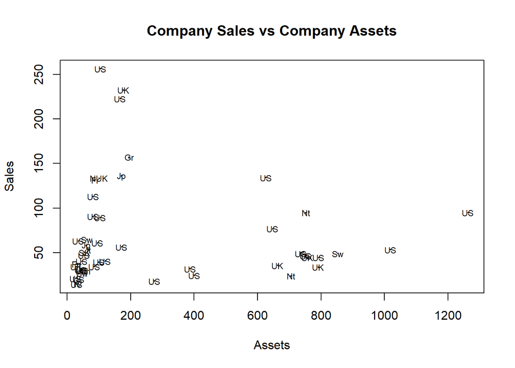

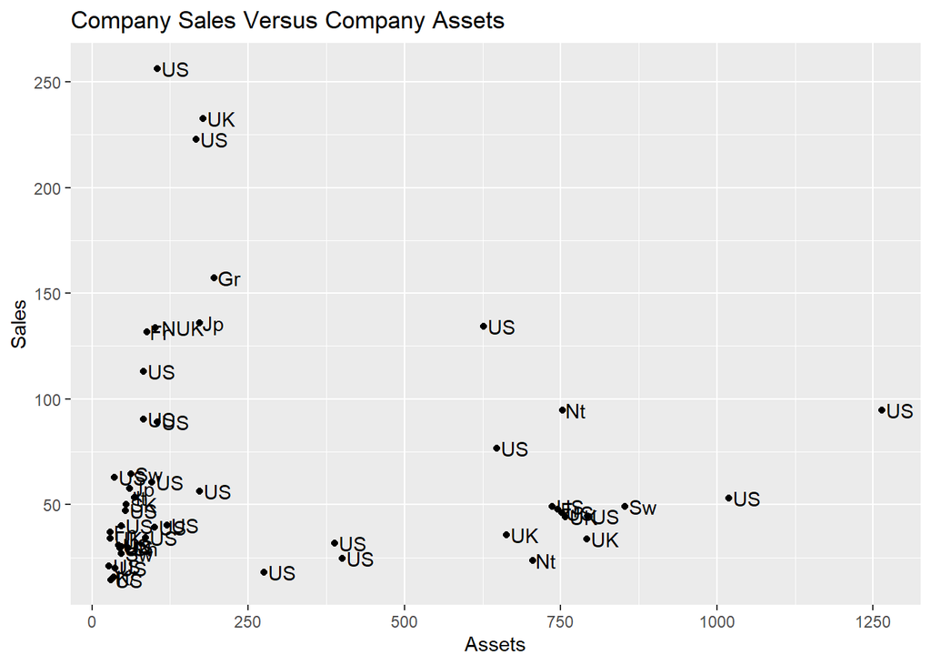

  |  | Country | Mean_Sales | Profits_Greater_Than_5bil |
  | --- | --- | --- | --- |
  | 60 | United States | 10.058256 | 20 |
  | 52 | Switzerland | 12.456765 | 3 |
  | 56 | United Kingdom | 10.445109 | 3 |
  | 37 | Netherlands/ United Kingdom | 92.100000 | 1 |
  | 18 | Germany | 20.781385 | 1 |
  | 16 | France | 20.102063 | 1 |
  | 28 | Japan | 10.190633 | 1 |
  | 49 | South Korea | 7.969333 | 1 |
  | 12 | China | 5.099600 | 1 |
  | 36 | Netherlands | 17.020714 | 0 |

  [output cut: 10 more lines]

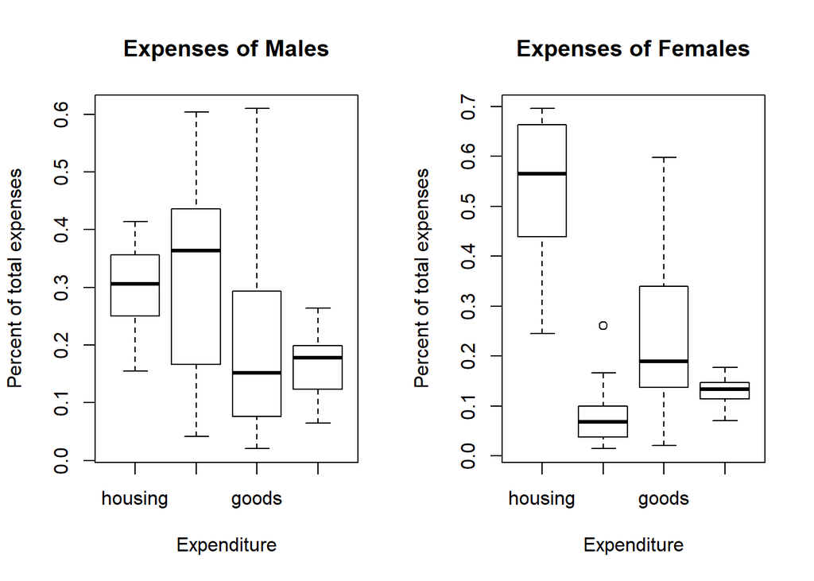

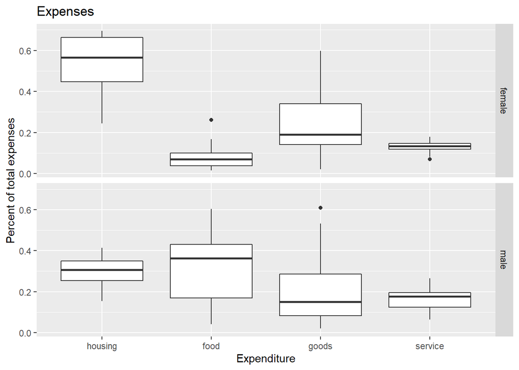

- Discussion: The data was already preloaded into R under *household*. In order to get all of the expenditures to have similar meaning, I think they should be divided by the total expenses to get a proportion. Then the total column is deleted so all that is left is the proportion of the total that each expense is per person. Since I don’t know how to make graphs with each of the columns being a different variable, I shifted the data from a wide format to a long format which allows the selection of a column to be automatically split based on factor level. Then each expense is plotted using the base R *boxplot()* function and a *ggplot()* function.
- For the first question that we wanted answered, if the expense on commodity group depends on the total expenses, we can see that for some categories like the food and service commodities for females doesn’t really change in proportions no matter how much they spend over all, where the housing and goods categories do change a fair amount; females spent between about 25% and 70 percent on housing while spending close to 0% to 18% (with the exception of 1 data point that is an outlier) on food. Males also had shown some differences. Males were fairly consitent in the percent of their spending that went to housing and services while being really variable in their food and goods expenditures.
- For the second question, differences in males and females can be seen in the housing and food categories. Men appeared to be more consistent in their housing spending and higher variation in their food spending while females tended to be more consistent in their food spending, but more variable in their housing spending. However, both males and females had a large variation in their goods spending depending on how much they spent overall and both were rather consistent in their service spending.
  - A difficulty was getting the graphs to look right with them being on the same ‘plate’. The *boxplot()* function doesn’t look very good when they are plotted over top of each other, while ggplot does. The function from ggplot also makes it easier to visualize when gender is stacked rather than side by side. Also, figuring out that I couldn’t (or didn’t know how) to use the same data frame for both the base R and the ggplot2 functions to make similar output took some time. I referred back to the lecture **.R** file for the ggplot problem since the R Graphics Cookbook didn’t help.
  - I think it is important that the proportions of total expenses of males and females differ in Housing and food. It is also really interesting that goods and services were similar in variation between males and females. From the way the plots were calculated, it shows that males and females are pretty consistent in spending about 15% of their total expenditures on services.
7. Question 2.3, pg. 41 in Handbook (see Chapter 6 of R Graphcis Cookbook for GGPlot)
- Statement/Question: Construct side-by-side box plots for the data for the different age groups in the *suicide2* data frame and comment on what the plot tells me about the data.

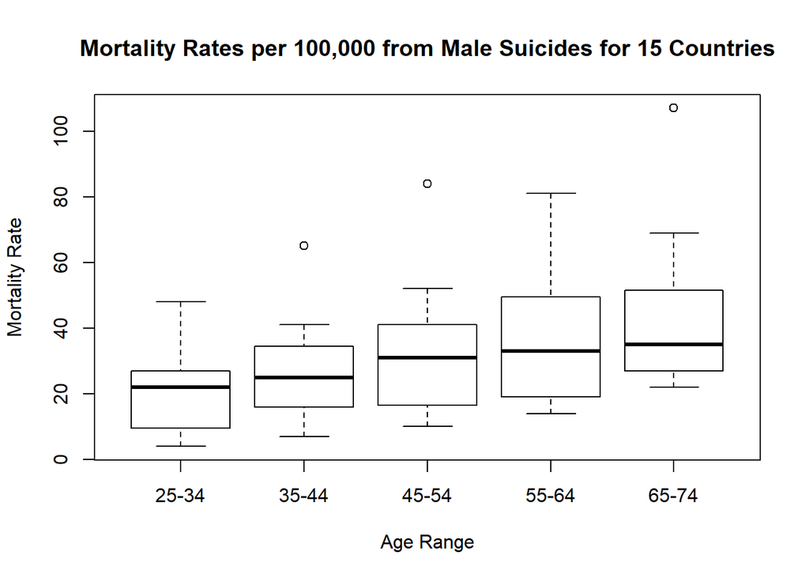

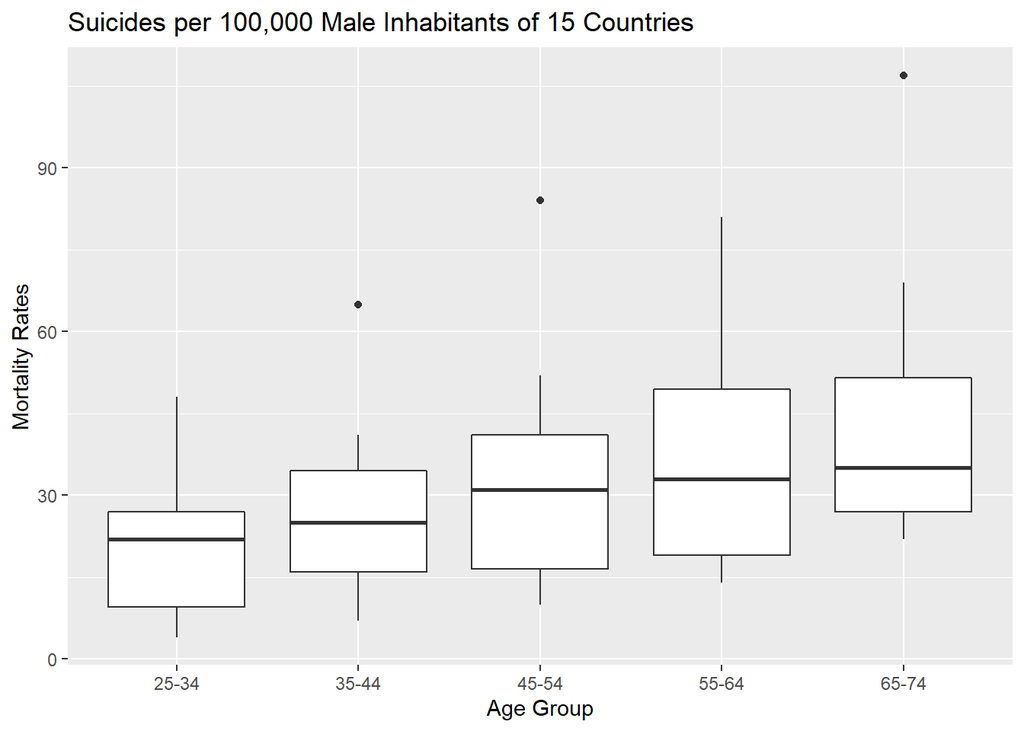

```
## [1] 91.9212
```

```
## [1] TRUE
```

- Discussion: This problem was fairly straight forward. A new column was created with the value of the **x - µ** was created and than the median of that column was found using *median()*. This value was than multiplied by the given 1.4826 and then reported. The boolean operator **=** was used make sure that this value was the same value found using the *mad()* function. **TRUE** means the values are the same.

**No quesiton number 9?**

10. Using the data matrix , find the state with the minimum per capita income in the New England region as defined by the factor . Use the vector to get the state name.

```
## [1] "Maine"
```

```
##         Model Min.Price Max.Price MPG.highway Weight
## 16 Lumina_APV      14.7      18.0          23   3715
## 17      Astro      14.7      18.6          20   4025
## 26    Caravan      13.6      24.4          21   3705
## 28    Stealth      18.5      33.1          24   3805
## 36   Aerostar      14.5      25.3          20   3735
## 48        Q45      45.4      50.4          22   4000
## 49      ES300      27.5      28.4          24   3510
## 50      SC300      34.7      35.6          23   3515
## 56        MPV      16.6      21.7          24   3735
## 63   Diamante      22.4      29.9          24   3730
## 66      Quest      16.7      21.5          23   4100
## 70 Silhouette      19.5      19.5          23   3715
## 87     Previa      18.9      26.6          22   3785
## 89    Eurovan      16.6      22.7          21   3960
```

- Discussion: Similarly to question 10, the *Cars93* data was subset to include data that includes highway MPG less than 25, and a weight greater than 3500 pounds. Following subsetting of the data, the model name, min and max price, the vehicles highway MPG, as well as the vehicle weight were printed out.
12. Form a matrix object named from the variables from the dataframe from the package. Use it to create a list object named containing named components as follows:
    1. A vector of means, named
    2. A vector of standard errors of the means, named

```
## $Cars.Means
##   Min.Price   Max.Price    MPG.city MPG.highway  EngineSize      Length
##   17.125806   21.898925   22.365591   29.086022    2.667742  183.204301
##      Weight
## 3072.903226
##
## $Cars.Std.Errors
##   Min.Price   Max.Price    MPG.city MPG.highway  EngineSize      Length
##   0.9069210   1.1438051   0.5827473   0.5528742   0.1075695   1.5141964
##      Weight
##  61.1694186
```

- Discussion: In order to calculate the *Cars.Means* vector, *colMeans()* was used. However to calculate the standard error of the column means, a temporary vector was created using the *Cars.Means* vector. Each column was looped over in order to calculate the standard error of the mean wish the value being written to the appropriate place in the vector. The new vector was then added to the *Cars.Stats* list under *Cars.Std.Errors* title.
13. Use the function on the three-dimensional array to compute:
    1. Sample means of the variables , for each of the three species

    ```
    ##            Sepal L. Sepal W. Petal L. Petal W.
    ## Setosa        5.006    3.428    1.462    0.246
    ## Versicolor    5.936    2.770    4.260    1.326
    ## Virginica     6.588    2.974    5.552    2.026
    ```

    2. Sample means of the variables for the entire data set.

    ```
    ## Sepal L. Sepal W. Petal L. Petal W.
    ## 5.843333 3.057333 3.758000 1.199333
    ```

    ```
    ##     Northeast         South North Central          West
    ##      4570.222      4011.938      4611.083      4702.615
    ```

    ```
    ##        New England    Middle Atlantic     South Atlantic
    ##          0.9166667          1.1666667          1.5000000
    ## East South Central West South Central East North Central
    ##          1.9500000          2.0000000          0.8000000
    ## West North Central           Mountain            Pacific
    ##          0.6285714          0.9500000          1.1400000
    ```

    3. The number of states in each region

    ```
    ##     Northeast         South North Central          West
    ##             9            16            12            13
    ```

- Discussion: This was more simple thn the iris data, most likely since it’s only working with 2 dimension. The average income for each region is stated in **a)**, after adding *state.region* to the *state* data frame used in Question 10.
- Illiteracy rate was also relatively easy since the data frame is already created. The illiteracy rate for the West North Central (our division) being the lowest was unexpected. I expected the illiteracy rate being the lowest in the New England division.
- In order to find the number of states in a particular region, I first tried to use the *sum()* function but found out that it wouldn’t recognise an input of factors and then find the sum of them, so instead the unique function was used to find the different states in the *name* column based on the region, then the length of the unique names list was output.
  - The only complication found in this exercise was the writing of the function in *c)*, however this was a quick fix. It might be important that the income of the West region being higher might not be related to the standard of living. It may also be important that the number of states in each region aren’t evenly distributed, with the Northeast having the least number and the South having the greatest number.
15. Using the dataframe , produce a scatter plot matrix of the variables . Use different colors to identify cars belonging to each of the categories defined by the variable in different colors.

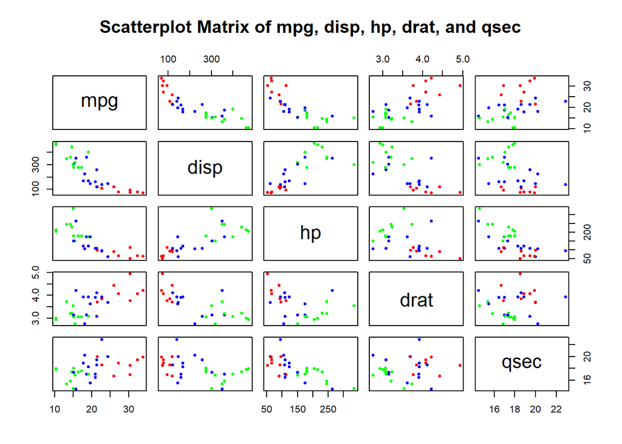

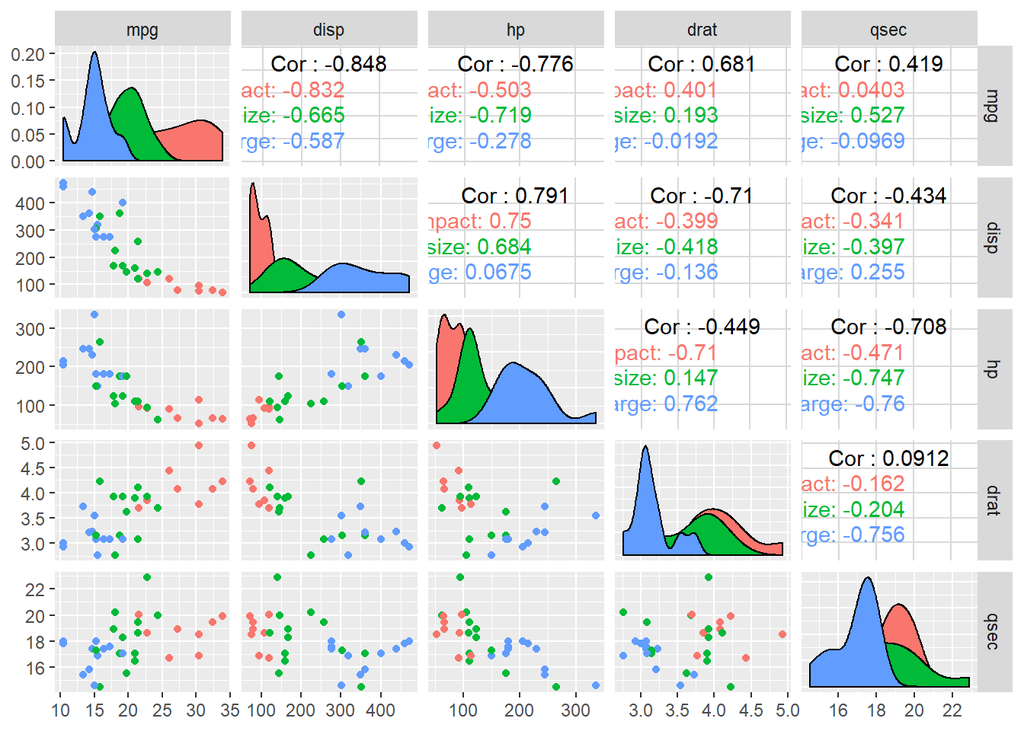

    ```r
    carsize = cut(mtcars[,"wt"], breaks=c(0, 2.5, 3.5, 5.5),
    + labels = c("Compact","Midsize","Large"))
    ```

- Discussion: The plots were made with both base R (*pairs*) and *ggpairs*. The given code for carsize was used to create a new column of “size” and that column was used to set colors to red, blue, and green for the base R plot. The column of size was given directly to the *ggpairs* funciton and it chose the colors.
  - There looks to be a relationship between mpg and disp, mpg and hp, and disp and hp, which makes some sense; mpg goes down with more power and larger engine, and hp would increase with a larger engine.
  - The *ggpairs* plot is much more informative than the plot from base R because it provides more information like the correlation between the 2 continuous variables. The *ggpairs* also gives a density plot which is easier to observe than with just the scatterplot.
16. Use the function to perform a one-way analysis of variance on the data with as the treatment factor. Assign the result to an object named and use it to print an ANOVA table.

```
##             Df Sum Sq Mean Sq F value   Pr(>F)
## feed         5 231129   46226   15.37 5.94e-10 ***
## Residuals   65 195556    3009
## ---
## Signif. codes:  0 '***' 0.001 '**' 0.01 '*' 0.05 '.' 0.1 ' ' 1
```

- Discussion: The main source of variance in the data is between the different feeds, and not within individual feeds. The p-value states that we can reject the null hypothesis that the mean chick weight of 6 different feed types are equal, and conclude there some feed types produce higher weights in chicks. The assumptions that need to be made in order to do an analysis of variance is normality of the distribution and that the variances are equal.
17. Write an R function named for conducting a one-sample t-test. Return a list object containing the two components:
    - the t-statistic named T;
    - the two-sided p-value named P.

Use this function to test the hypothesis that the mean of the variable (in the dataset) is equal to 240 against the two-sided alternative.

```r
#create t-test function
ttest = function(x, mu){
    m = mean(x)
    n = length(x)
    s = sd(x)
    t = (m - mu)/(s/sqrt(n))
    p = 2*pt(-abs(t), df=n-1)
    return(list("T" = t, "P" = p))
}

ttest(chickwts$weight, 240)
```

```
## $T
## [1] 2.299879
##
## $P
## [1] 0.02444107
```

- Checking if it matches *t.test()*

```
##
##  One Sample t-test
##
## data:  chickwts$weight
## t = 2.2999, df = 70, p-value = 0.02444
## alternative hypothesis: true mean is not equal to 240
## 95 percent confidence interval:
##  242.8301 279.7896
## sample estimates:
## mean of x
##  261.3099
```

- Discussion: In order to perform a one-sample t-test, an assumption being made is that the data is normally distributed. The 4 pieces of information needed to calculate the t-statistic in R is the mean, standard deviation, and length of the data array, as well as the value that we want to see if it is similar to. The t-statistic can than be calculated and with the t-statistic the pvalue can be calculated.
  - The only complication I had was trying to figure out how to do the p-value. The creation of the function was straight forward.
  - The p-value is below 0.05, at 0.02, which means that there is sufficient evidence to reject the null hypothesis that the overall chick weight mean is equal to 240.

*Resources Used*:

- StackOverflow
- rkabacoff.github.io/datavis/Customizing.html
- nabble.com
- cyclismo.org